# Model Inferences

Kristian Brock

16 September, 2019

Modelling of the event rates in the observed series is presented in DLTSeriesPresentation and ObjRespSeriesPresentation. Inferences beyond those series-specific insights are explored here.

```r
# # This script in the root of the project loads the datasets
# source('../../../Load.R')

library(dplyr)
library(brms)
library(tidybayes)
library(ggplot2)
library(ggridges)
# Load DLT model
dlt_mod <- readRDS('dlt_mod.rds')

# Load objective response model
obj_resp_mod <- readRDS('obj_resp_mod.rds')
```

## DLT Model

Effect of ContainsChemo

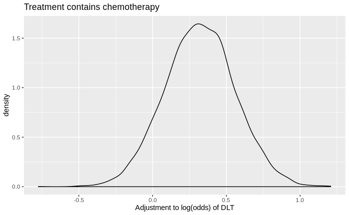

```r
dlt_mod %>%
  spread_draws(b_FixedDoseChemo) %>%
  ggplot(aes(x = b_FixedDoseChemo)) +
  geom_density() +
  labs(x = 'Adjustment to log(odds) of DLT',
       title = 'Treatment contains chemotherapy') +
  theme(legend.position = 'none')
```

Mean or baseline or expected event rate. Note that the baseline rate adjustment for chemo is no longer captured by one variable. The samples for the ContainsChemo intercept adjustment should be added to the Chemo random effects: TODO: does this make sense?

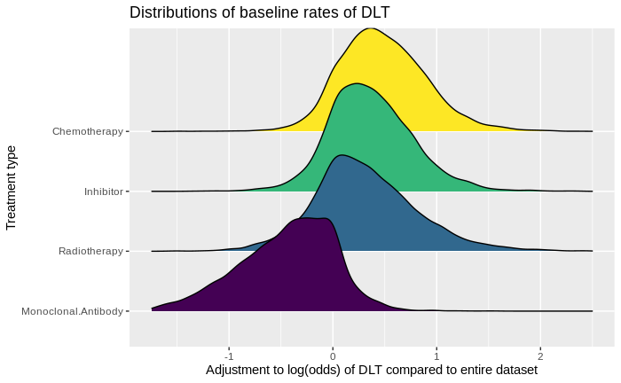

```r
dlt_mod %>%
  spread_draws(r_DoseVaryingTreatmentType[TmtType,term]) %>%
  filter(TmtType %in% c('Radiotherapy', 'Monoclonal.Antibody', 'Inhibitor',
                        'Chemotherapy')) %>%
  filter(term == 'Intercept') %>%
  rename(ParamValue = r_DoseVaryingTreatmentType) %>%
  mutate(TmtTypeO = factor(TmtType, levels = c('Monoclonal.Antibody',
                                                   'Radiotherapy',
                                                   'Inhibitor',
                                                   'Chemotherapy'),
                               ordered = TRUE)) %>%
  ggplot(aes(y = TmtTypeO, group = TmtTypeO, fill = TmtTypeO,
             x = ParamValue)) +
  geom_density_ridges() +
  labs(x = 'Adjustment to log(odds) of DLT compared to entire dataset',
       y = 'Treatment type',
       title = 'Distributions of baseline rates of DLT') +
  theme(legend.position = 'none') +
  xlim(-1.75, 2.5)
```

After adjusting for the heterogeneity seen in the individual series, adding chemo, inhibitors, or radiotherapy probably increases DLT risk, as we would expect. Notably, incidence of DLT is less common when monoclonal antibodies are investigated.

Sensitivity of event to increases in dose

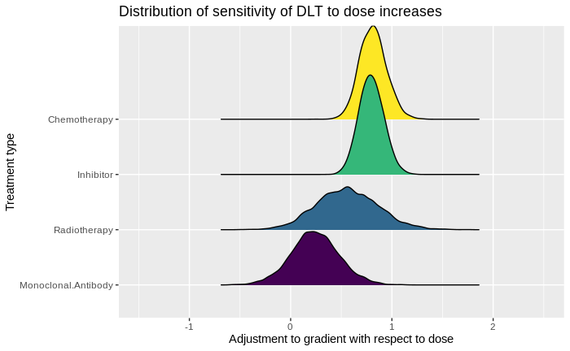

```r
dlt_mod %>%
  spread_draws(r_DoseVaryingTreatmentType[TmtType,term]) %>%
  filter(TmtType %in% c('Radiotherapy', 'Monoclonal.Antibody', 'Chemotherapy',
                        'Inhibitor')) %>%
  mutate(TmtTypeO = factor(TmtType, levels = c('Monoclonal.Antibody',
                                               'Radiotherapy',
                                               'Inhibitor',
                                               'Chemotherapy'),
                           ordered = TRUE)) %>%
  filter(term == 'DoseLevel') %>%
  ggplot(aes(y = TmtTypeO, group = TmtTypeO, fill = TmtTypeO,
             x = r_DoseVaryingTreatmentType)) +
  geom_density_ridges() +
  labs(x = 'Adjustment to gradient with respect to dose',
       y = 'Treatment type',
       title = 'Distribution of sensitivity of DLT to dose increases') +
  theme(legend.position = 'none') +
  xlim(-1.5, 2.5)
```

With chemotherapies, inhibitors, and radiotherapy, the relationship of DLT risk with dose is convincingly positive. That is, greater doses of these treatments are associated with greater risk of DLT. The message is rather more opaque with antibodies. The aggregate evidence supports a positive relationship, but the strength of the relationship is rather weaker than the other drug classes and could plausbily be very small.

All treatment types:

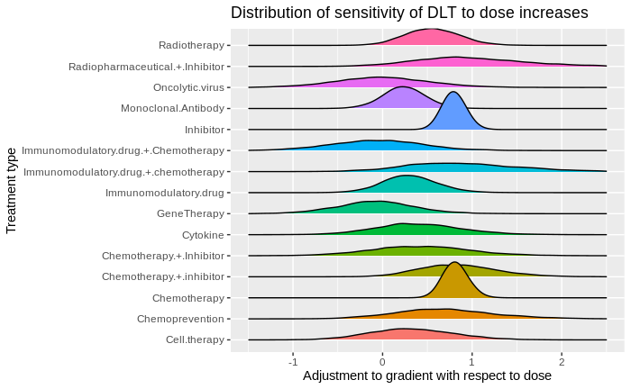

```r
dlt_mod %>%
  spread_draws(r_DoseVaryingTreatmentType[TmtType,term]) %>%
  filter(term == 'DoseLevel') %>%
  ggplot(aes(y = TmtType, group = TmtType, fill = TmtType,
             x = r_DoseVaryingTreatmentType)) +
  geom_density_ridges() +
  labs(x = 'Adjustment to gradient with respect to dose',
       y = 'Treatment type',
       title = 'Distribution of sensitivity of DLT to dose increases') +
  theme(legend.position = 'none') +
  xlim(-1.5, 2.5)
```

There is more positive mass than negative mass, suggesting that the opposite must be seen in the AnalysisSeriesId-level analyses?

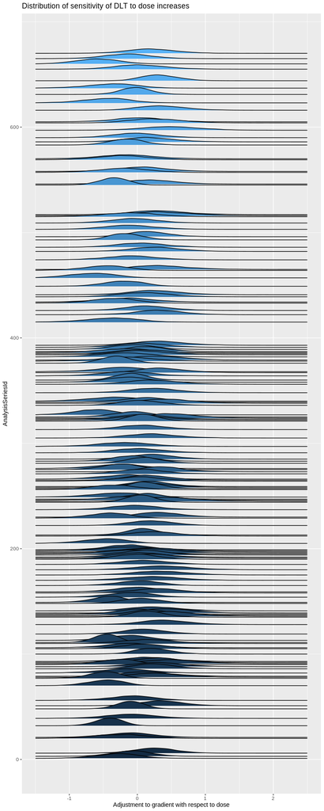

```r
dlt_mod %>%
  spread_draws(r_AnalysisSeriesId[AnalysisSeriesId,term]) %>%
  filter(term == 'DoseLevel') %>%
  ggplot(aes(y = AnalysisSeriesId, group = AnalysisSeriesId,
             fill = AnalysisSeriesId, x = r_AnalysisSeriesId)) +
  geom_density_ridges() +
  labs(x = 'Adjustment to gradient with respect to dose',
       title = 'Distribution of sensitivity of DLT to dose increases') +
  theme(legend.position = 'none') +
  xlim(-1.5, 2.5)
```

Woof. How would you know?

## Objective Response Model

Effect of ContainsChemo

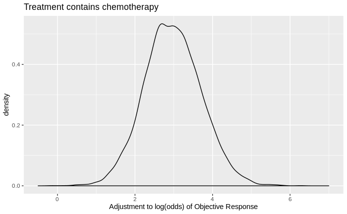

```r
obj_resp_mod %>%
  spread_draws(b_FixedDoseChemo) %>%
  ggplot(aes(x = b_FixedDoseChemo)) +
  geom_density() +
  labs(x = 'Adjustment to log(odds) of Objective Response',
       title = 'Treatment contains chemotherapy') +
  theme(legend.position = 'none') +
  xlim(-0.5, 7)
```

Expected response rate is much higher when fixed-dose chemo is used.

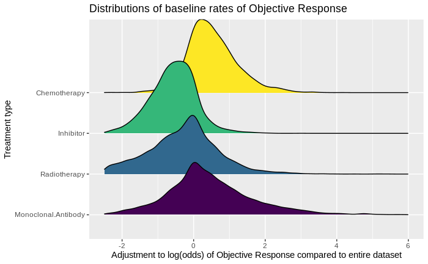

```r
obj_resp_mod %>%
  spread_draws(r_DoseVaryingTreatmentType[TmtType,term]) %>%
  filter(TmtType %in% c('Radiotherapy', 'Monoclonal.Antibody',
                        'Chemotherapy', 'Inhibitor')) %>%
  filter(term == 'Intercept') %>%
  rename(ParamValue = r_DoseVaryingTreatmentType) %>%
  mutate(TmtTypeO = factor(TmtType, levels = c('Monoclonal.Antibody',
                                               'Radiotherapy',
                                               'Inhibitor',
                                               'Chemotherapy'),
                           ordered = TRUE)) %>%
  filter(term == 'Intercept') %>%
  ggplot(aes(y = TmtTypeO, group = TmtTypeO, fill = TmtTypeO,
             x = ParamValue)) +
  geom_density_ridges() +
  labs(x = 'Adjustment to log(odds) of Objective Response compared to entire dataset',
       y = 'Treatment type',
       title = 'Distributions of baseline rates of Objective Response') +
  theme(legend.position = 'none') +
  xlim(-2.5, 6)
```

Sensitivity of event to increases in dose

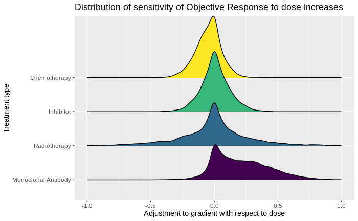

```r
obj_resp_mod %>%
  spread_draws(r_DoseVaryingTreatmentType[TmtType,term]) %>%
  filter(TmtType %in% c('Radiotherapy', 'Monoclonal.Antibody', 'Chemotherapy',
                        'Inhibitor')) %>%
  mutate(TmtTypeO = factor(TmtType, levels = c('Monoclonal.Antibody',
                                               'Radiotherapy',
                                               'Inhibitor',
                                               'Chemotherapy'),
                           ordered = TRUE)) %>%
  filter(term == 'DoseLevel') %>%
  ggplot(aes(y = TmtTypeO, group = TmtTypeO, fill = TmtTypeO,
             x = r_DoseVaryingTreatmentType)) +
  geom_density_ridges() +
  labs(x = 'Adjustment to gradient with respect to dose',
       y = 'Treatment type',
       title = 'Distribution of sensitivity of Objective Response to dose increases') +
  theme(legend.position = 'none') +
  xlim(-1.0, 1.0)
```